# Introduction to hydrorecipes

The **hydrorecipes** package aims to provide a few steps to improve the analysis of water level responses using moderately sized datasets (millions of rows). It aims to work seamlessly within the **tidymodels** framework of packages. While the package was designed for water levels and pore-pressures, the *steps* may be useful in other fields of study. Examples in the introduction focus on barometric pressure and Earth tides, the *steps* may also be applied to precipitation, river stage, ocean tides, and pumping responses.

```r
library(hydrorecipes)
library(earthtide)
library(ggplot2)
library(splines2)
library(tidyr)

data(transducer, package = "hydrorecipes")
head(transducer)
```

```
#>              datetime       wl     baro       et
#> 1 2016-08-25 00:00:00 13.32769 9.482164 38.82942
#> 2 2016-08-25 00:02:00 13.32797 9.482288 37.72395
#> 3 2016-08-25 00:04:00 13.32830 9.482298 36.66907
#> 4 2016-08-25 00:06:00 13.32770 9.482159 35.66541
#> 5 2016-08-25 00:08:00 13.32740 9.481697 34.71358
#> 6 2016-08-25 00:10:00 13.32735 9.481246 33.81418
```

```r
transducer$datetime_num <- as.numeric(transducer$datetime)
```

This data contains (~1.5 months) of timestamped water pressure, barometric pressure and synthetic Earth tide data with a 2 minute sampling frequency. Our goal is to relate the water pressure data to the barometric, Earth tides in the presence of a background trend. We will look at a few different ways to analyze this dataset. For more information on the **recipes** package and **tidymodels** please see: https://recipes.tidymodels.org

## Modified Toll and Rasmussen 2007

To start with we will use the **recipes** package alone using a modified Toll and Rasmussen, 2007 approach. We use logarithmically spaced lags instead of regularly spaced ones to improve computational performance and use the non-difference based approach. *step_ns* is used to characterize the background trend.

```r
rec_toll_rasmussen <- recipe(wl~baro+et+datetime_num, transducer) |>
  step_lead_lag(baro, lag = log_lags(100, 86400 * 2 / 120)) |>
  step_lead_lag(et, lag = seq(0, 180, 20)) |>
  step_ns(datetime_num, deg_free = 10) |>
  prep()
input_toll_rasmussen <- rec_toll_rasmussen |> bake(new_data = NULL)
```

```r
fit_toll_rasmussen <- lm(wl~., input_toll_rasmussen)
```

## Modified Rasmussen and Mote 2007

Next we will use the **recipes** package alone using a modified Rasmussen and Mote, 2007 approach. We use logarithmically spaced lags instead of regularly spaced ones to improve computational performance and use the non-difference based approach. *step_ns* is used to characterize the background trend.

```r
tidal_freqs <- c(0.89324406, 0.92953571, 0.96644626, 1.00273791, 1.03902956,
                 1.07594011, 1.86454723, 1.89598197, 1.93227362, 1.96856526,
                 2.00000000, 2.89841042)
rec_rasmussen_mote <- recipe(wl~baro+datetime_num, transducer) |>
  step_lead_lag(baro, lag = log_lags(100, 86400 * 2 / 120)) |>
  step_harmonic(datetime_num,
                frequency = tidal_freqs,
                cycle_size = 86400,
                keep_original_cols = TRUE) |>
  step_ns(datetime_num, deg_free = 10) |>
  prep()
input_rasmussen_mote <- rec_rasmussen_mote |> bake(new_data = NULL)
```

```r
fit_rasmussen_mote <- lm(wl~., input_rasmussen_mote)
```

## Kennel 2020 method for water levels

This is the method of Kennel 2020 which uses a distributed lag model (Almon, 1965, Gasparrini, 2011) and the [earthtide package](https://CRAN.R-project.org/package=earthtide) to generate synthetic wave groups. The distributed lag model was inspired by the [dlnm package](https://CRAN.R-project.org/package=dlnm), but adapted for datasets with millions of rows and long maximum time lags.

```r
wave_groups <- earthtide::eterna_wavegroups
wave_groups <- na.omit(wave_groups[wave_groups$time == '1 month', ])
wave_groups <- wave_groups[wave_groups$start > 0.5, ]
latitude  <- 34.0
longitude <- -118.5
rec_dl <- recipe(wl~baro+datetime_num, transducer) |>
  step_distributed_lag(baro, spline_fun = splines2::bSpline,
                       knots = log_lags(15, 86400 * 2 / 120)) |>
  step_earthtide(datetime_num,
                 latitude = latitude,
                 longitude = longitude,
                 astro_update = 1,
                 cutoff = 1e-5,
                 wave_groups = wave_groups) |>
  step_ns(datetime_num, deg_free = 10) |>
  prep()

input_dl <- rec_dl |> bake(new_data = NULL)
```

```r
fit_dl <- lm(wl~., input_dl)
```

We can compare the three models and they give similar results. The distributed lag version is particularly suited to long lag times and large datasets (small sampling interval). *step_earthtide* allows for easily estimating phase shifts unlike *step_harmonic* and the lagged version.

```r
model_results <- rbind(broom::glance(fit_dl),
                       broom::glance(fit_toll_rasmussen),
                       broom::glance(fit_rasmussen_mote)
)
model_results$name <- c('kennel_2020',
                        'toll_rasmussen_2007',
                        'rasmussen_mote_2007'
)
knitr::kable(model_results[,c('name', 'r.squared', 'sigma',
                              'AIC', 'BIC', 'df.residual', 'nobs')])
```

| name | r.squared | sigma | AIC | BIC | df.residual | nobs |
| --- | --- | --- | --- | --- | --- | --- |
| kennel_2020 | 0.9999329 | 0.0003556 | -460205.1 | -459756.2 | 35229 | 35281 |
| toll_rasmussen_2007 | 0.9999324 | 0.0003572 | -459817.6 | -458784.1 | 35160 | 35281 |
| rasmussen_mote_2007 | 0.9999324 | 0.0003573 | -459789.6 | -458637.5 | 35146 | 35281 |

## Decomposition

The water pressure dataset can be thought of as a sum of multiple components. The regression deconvolution method attempts to separate these components so that you can see the influence that each stress has on the resultant water pressure signal.

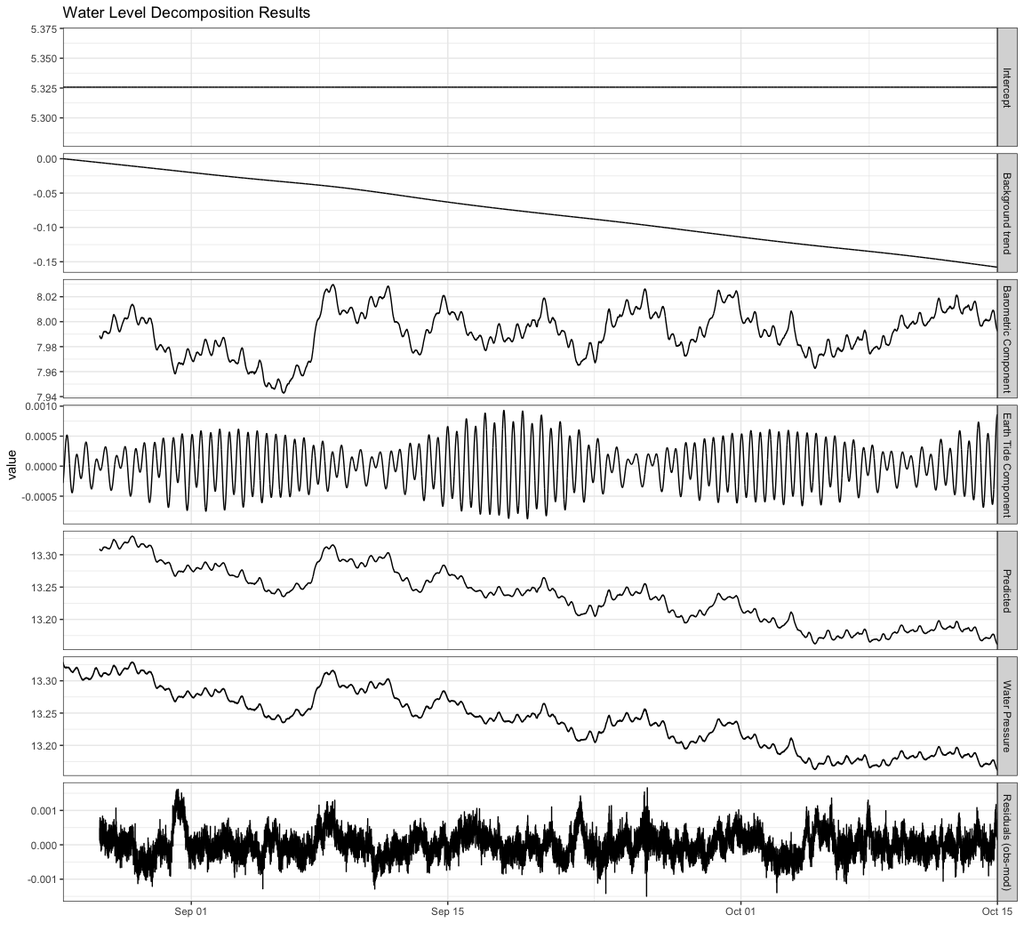

```r
pred <- predict_terms(fit = fit_dl,
                      rec = rec_dl,
                      data = input_dl)
pred <- bind_cols(transducer[, c('datetime', 'wl')], pred)
pred$residuals <- pred$wl - pred$predicted
pred_long <- pivot_longer(pred, cols = !datetime)
levels <-c('intercept', 'ns_datetime_num', 'distributed_lag_baro',
           'earthtide_datetime_num', 'predicted', 'wl', 'residuals')
labels <- c('Intercept', 'Background trend', 'Barometric Component',
            'Earth Tide Component', 'Predicted', 'Water Pressure',
            'Residuals (obs-mod)')
pred_long$name <- factor(pred_long$name,
                         levels = levels,
                         labels = labels)
ggplot(pred_long, aes(x = datetime, y = value)) +
  geom_line() +
  scale_y_continuous(labels = scales::comma) +
  scale_x_datetime(expand = c(0,0)) +
  ggtitle('Water Level Decomposition Results') +
  xlab("") +
  facet_grid(name~., scales = 'free_y') +
  theme_bw()
```

## Response

The response describes how the water pressure changes after there is a change in one of the input stresses. The **hydrorecipes** package describes the response in one of two ways; using harmonics, or a response function. These can be thought of as equivalent with one being in the time domain and the other the frequency domain. Both method provides similar information, but depending on the analysis model or background knowledge one may be preferred over the other. Below we use a response function for barometric pressure and harmonic analysis for the Earth tides.

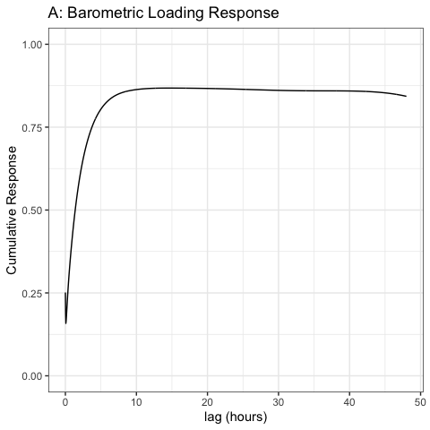

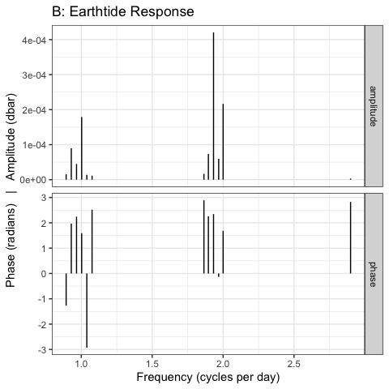

```r
resp    <- response(fit_dl, rec_dl)
resp_ba <- resp[resp$name == 'cumulative', ]
resp_ba <- resp_ba[resp_ba$term == 'baro', ]

ggplot(resp_ba, aes(x = x * 120 / 3600, y = value)) +
  ggtitle('A: Barometric Loading Response') +
  xlab('lag (hours)') +
  ylab('Cumulative Response') +
  scale_y_continuous(limits = c(0, 1)) +
  geom_line() +
  theme_bw()
resp_et <- resp[resp$name %in% c('amplitude', 'phase'), ]
ggplot(resp_et, aes(x = x, xend = x, y = 0, yend = value)) +
  geom_segment() +
  ggtitle('B: Earthtide Response') +
  xlab('Frequency (cycles per day)') +
  ylab('Phase (radians)   |   Amplitude (dbar)') +
  facet_grid(name~., scales = 'free_y') +
  theme_bw()
```

# References

Almon, S (1965). The Distributed Lag Between Capital Appropriations and Expenditures. Econometrica 33(1), 178.

Gasparrini A. Distributed lag linear and non-linear models in R: the package dlnm. Journal of Statistical Software. 2011; 43(8):1-20. https://doi.org/10.18637/jss.v043.i08

Kennel, J., 2020. High Frequency Water Level Responses to Natural Signals (Doctoral dissertation, University of Guelph). http://hdl.handle.net/10214/17890

Rasmussen, T.C. and Mote, T.L., 2007. Monitoring surface and subsurface water storage using confined aquifer water levels at the Savannah River Site, USA. Vadose Zone Journal, 6(2), pp.327-335.

Toll, N.J. and Rasmussen, T.C., 2007. Removal of barometric pressure effects and earth tides from observed water levels. Groundwater, 45(1), pp.101-105. Vancouver